# Visualisations of Operation Protective Edge

Iga Korneta

Wednesday, August 13, 2014

### Introduction

I first became interested in visualising [Operation Protective Edge](https://en.wikipedia.org/wiki/Operation_Protective_Edge) when I saw the huge lists of victims on the [IMEMC](http://www.imemc.org/article/68429) and [Al-Akhbar blog/journal](http://english.al-akhbar.com/node/20528) websites. I wanted to create some sort of a visual shorthand of the operation, beyond lists and statistics.

This document shows some of the results of my curiosity.

### Data sources and processing

#### Sources

I scraped the data from [IMEMC](http://www.imemc.org/article/68429), [Al-Akhbar](http://english.al-akhbar.com/node/20528) and, for the Israeli soldier fatalities, [Times of Israel](http://www.timesofisrael.com/fallen-idf-soldiers-in-operation-protective-edge/). Unfortunately, it turned out that the data was rather dirty, and thus required a lot of (irreproducible, unless you want to devote a lot of time to that) manual massaging.

In particular:

- IMEMC and Al-Akhbar use different Arabic-to-English transliterations;
- IMEMC only lists identified victims, Al-Akhbar lists all;
- multiple records differ on ages, locations etc. between the sources; some records are obviously repeated in both sources, with minor spelling errors etc..

My chosen procedure was common-sense and as follows:

- match mutually identified records where possible;
- match identified IMEMC records with “unknown” placeholder records from Al-Akhbar from the same date where possible;
- add placeholder records to the Al-Akhbar list as needed. Those placeholder records are identified as having post-decimal points digits. So, for example, “unknown1” is an original Al-Akhbar placeholder record, “unknown1.1” was added to facilitate list merging.

Because I chose a greedy procedure for merging, the list is slightly longer than the ‘official’ statistics. At the time of the data processing (Aug 12, 2014), the raw Al-Akhbar file has 1940 records. The final file has 2019 Palestinian records (in addition to 64 Israeli ones). 1102 of the Palestinian records repeat between the Al-Akhbar and IMEMC lists.

#### Processing

The final file contains the following variables:

- date, ordinal day (starting from July 8th, 2014 as the first day of the operation), ethnicity;
- full name, first name, last name, name summary, age, sex, place of death, circumstances from the Al-Akhbar file;

Gender data was derived by running the first names through [here](http://www.indiachildnames.com/genderof.aspx) and [here](http://www.gpeters.com/names/baby-names.php).

Name summary is a numerical shorthand for name, defined as ((ord(last_name_low[0])-96)*10+(ord(last_name_low[1])-96)), where ord(x)=ASCII value of x. (ord(a)-96)=1

- full name, name summary, age, sex, place of death, circumstances from the IMEMC file - column names starting from (IMEMC_);
- combined-record name summary, age, sex, and place of death; IMEMC records, which are supposed to be more correct, take precedence over Al-Akhbar records;
- age group, defined as: “Unknown”, “Child” (<=14), “Young adult” (<=24), “Adult” (<=54), “Elderly”;
- simulated ages and name summaries, for the plots where I wanted to add the “unidentified” records.

### Results

#### Exploratory analysis

Exploratory graphs show enrichment in the young male category:

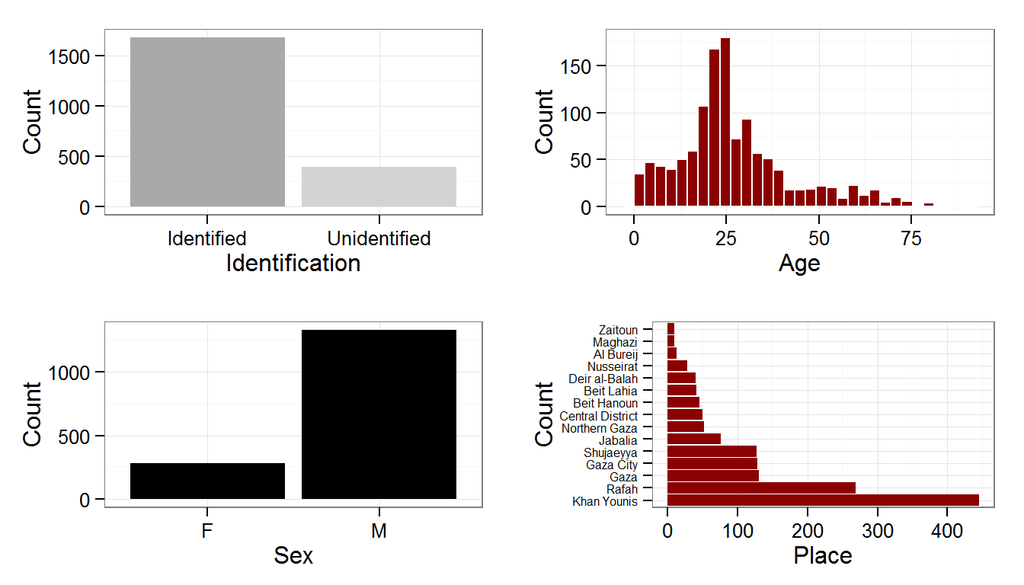

Side by side comparison of victim age stratification vs. the age stratification of the Gaza Strip (data from [Index Mundi](http://www.indexmundi.com/gaza_strip/demographics_profile.html)):

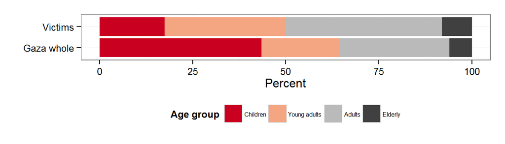

#### Victims by day of operation and Information updating

This plot show the cumulative deaths by day of operation:

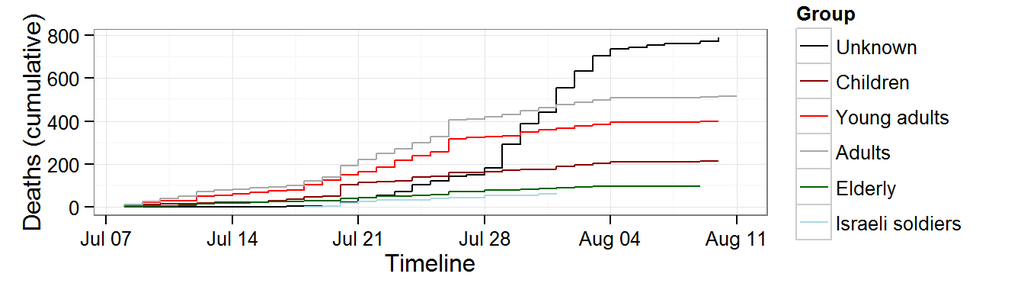

The “unknown” category will be pushed forward the more and more information there arrives. The Al-Akhbar website is not back-updated for new information regarding previously unidentified victims - thus freezing the initial status of the information.

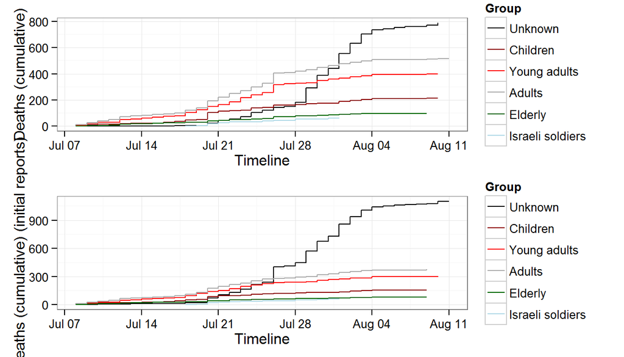

#### Final visualisations: the Hexbin and the Scatterplot

The goal of visual analytics is to bring order to chaos. Nevertheless, I was rather concerned about the ethics of doing so when it comes to summarising human deaths. It makes them too clean; too sterile. I wanted a visualisation that would show me the chaos - that would not shirk from it.

I started from a hexbin plot.

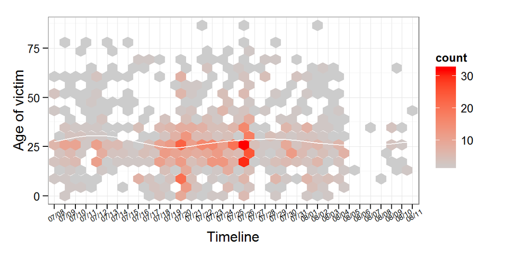

I added simulated age data to account for the yet-unidentified victims.

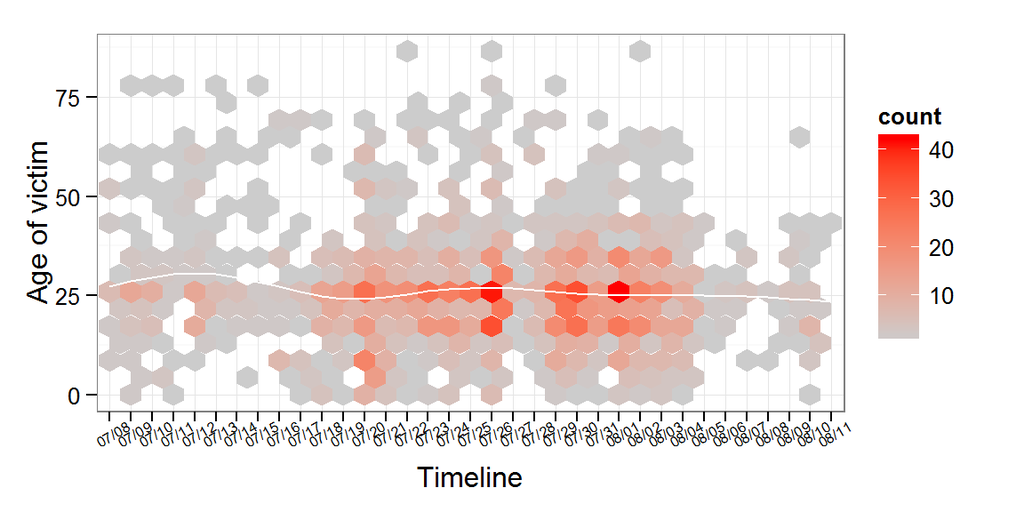

Then, I decided to abandon all pretense of a structure and use a scatterplot instead.

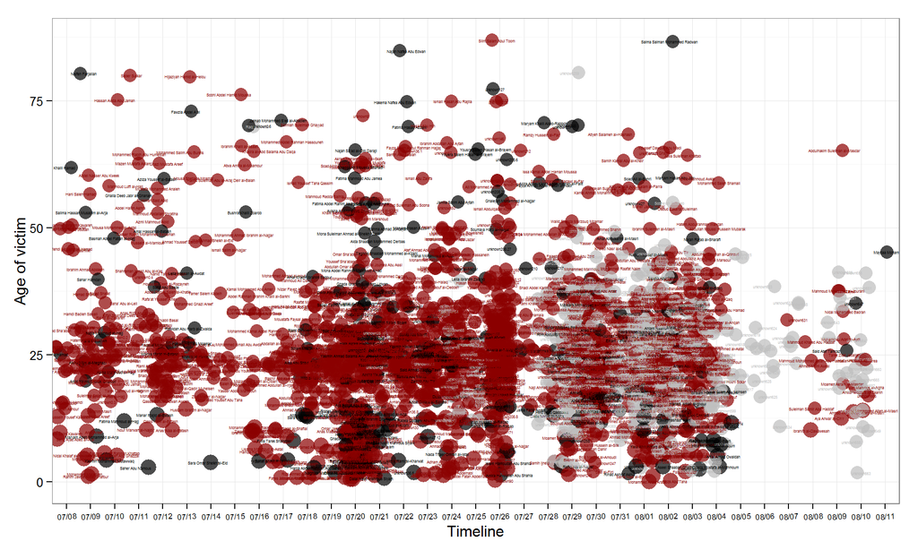

It’s possible to add the information about Israeli soldiers here:

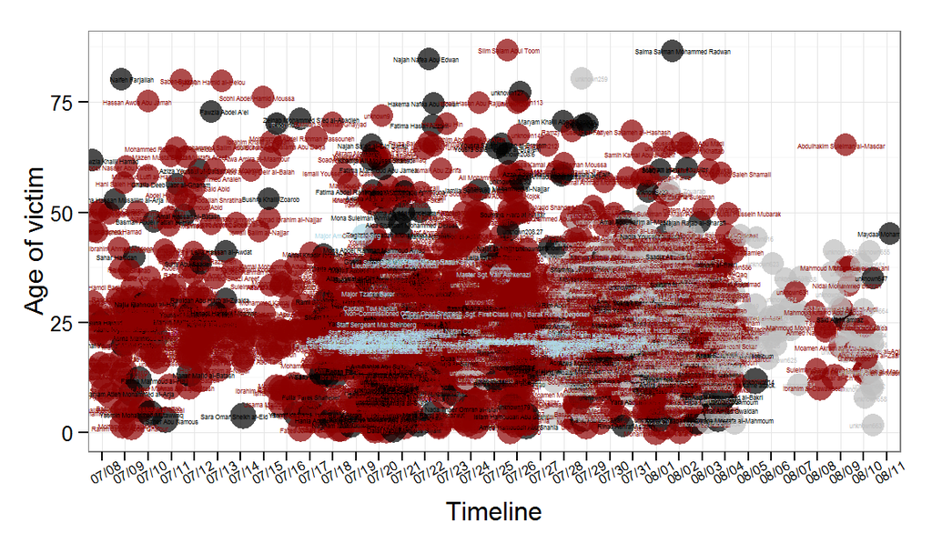

But it’s not really obligatory.